# Part II - Loan Data from Prosper

## by Sara Osama Kilany

## Investigation Overview

The purpose of this study was to explore how the Loan original amount varies with different features. The main variables of interest were the borrower state, Income range, Is borrower homeowner, and loan status.

## Dataset Overview

The Loan Data from Prosper that we used after preprocessing has 94843 records and 17 columns. We focus on the Loan original amount and its interaction with the borrower state, Income range, Is borrower homeowner, and loan status.

## Number of Borrowers per State-Top 5

We found that the top 5 states in terms of number of borrowers were CA, NY, FL, TX, and IL. CA has almost twice or more number of borrowers than each of the other 4 states.

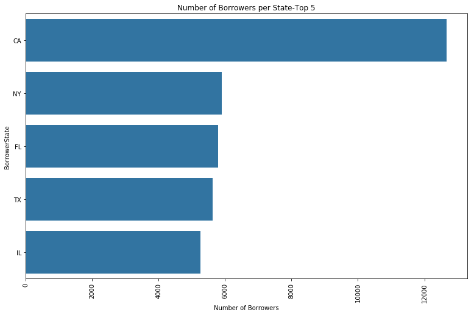

## Loan Original Amount Summary Statistics for Top 5 States

The median for the top 5 states in terms of number of borrowers have close median values for the loan original amount. The highest median in in TX. The largest variability is in CA.

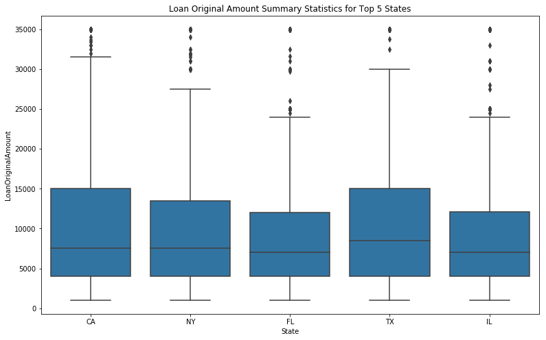

## Total Loan Original Amount per State- Top 5

CA has the largest sum of loan original amounts, almost twice those in NY and TX.

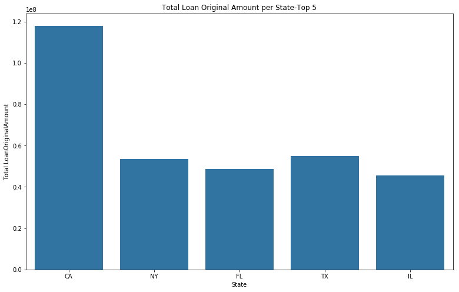

## Total Loan Amount by Income Range and Borrower Homeowner Status

For income range 100k+, borrowers who are home owners had the largest total loan amount. Home owners with income range 24.999k formed the least loan amount.

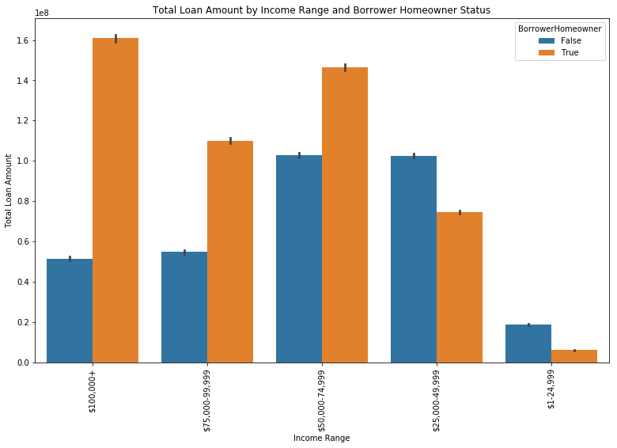

## Average Loan Amount by Income Range, Borrower Homeowner Status, and State (Top 5)

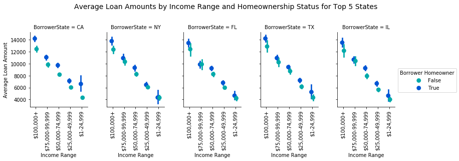

## Average Loan Original Amount by Income Range and Loan Status

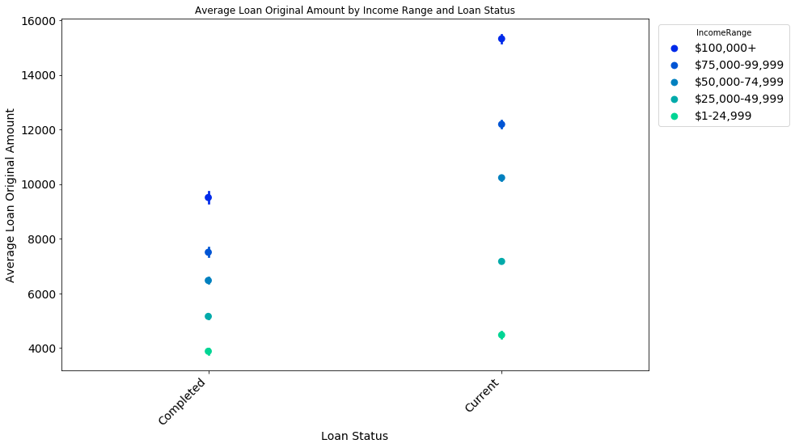